# My Clinical Analysis

2026-09-13 14:13:52.863974

## Summary

This report provides a comprehensive overview of the MultiConnector analysis performed.

### Data Overview

[output not shown]

## Exploratory Data Analysis

### Base Plot

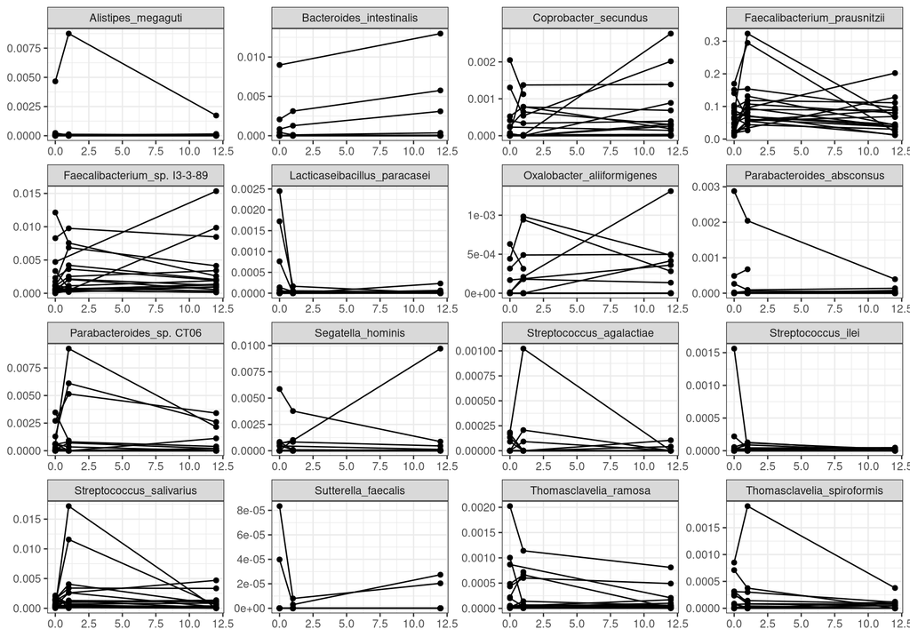

### Feature: EDSS_T0

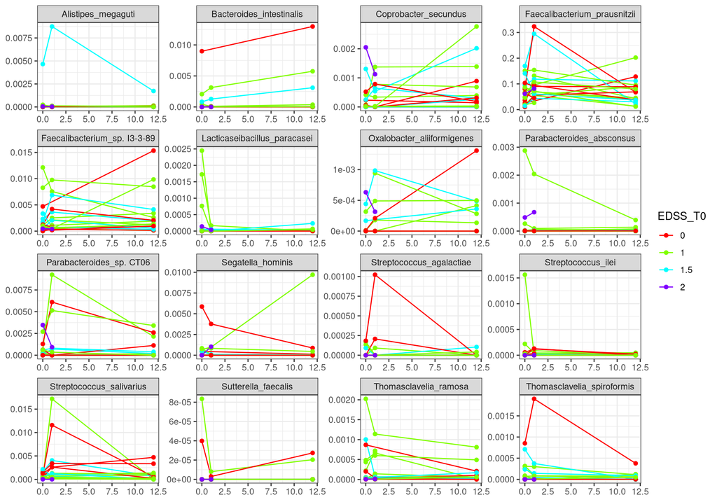

### Feature: EDSS_T12

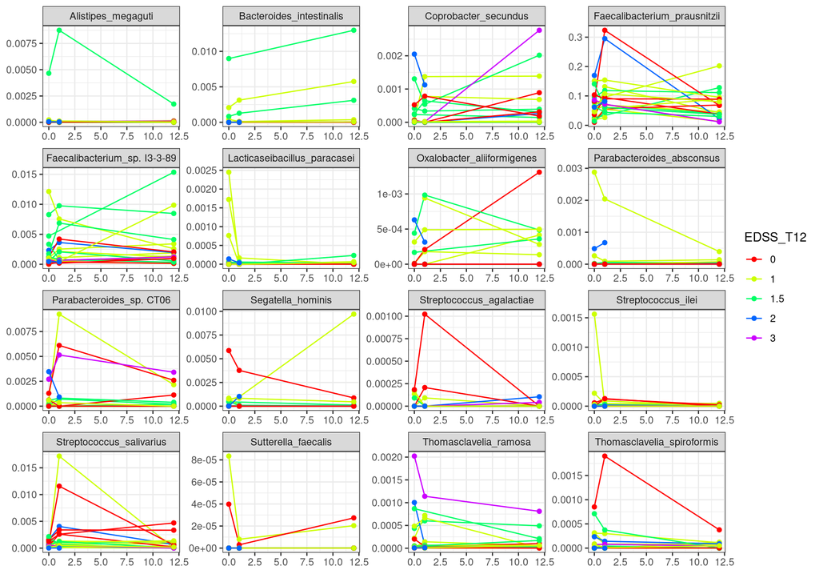

### Feature: sex

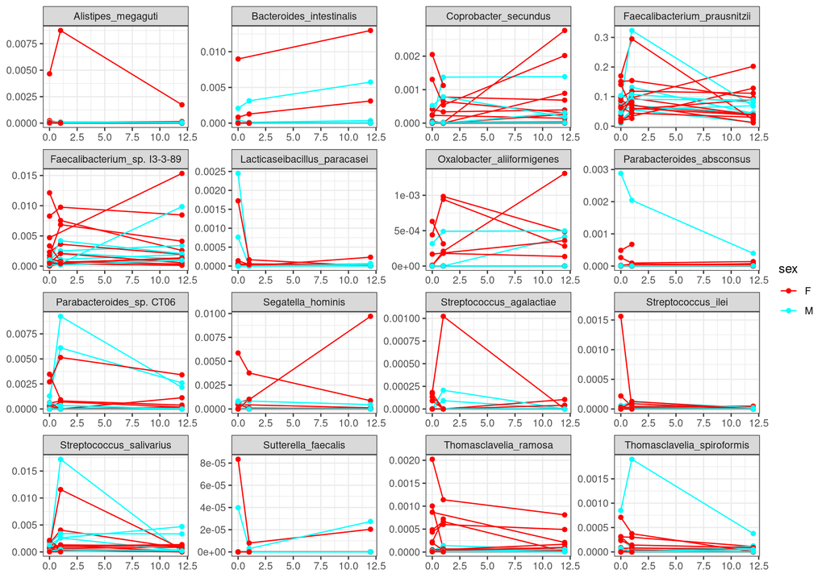

### Feature: naive

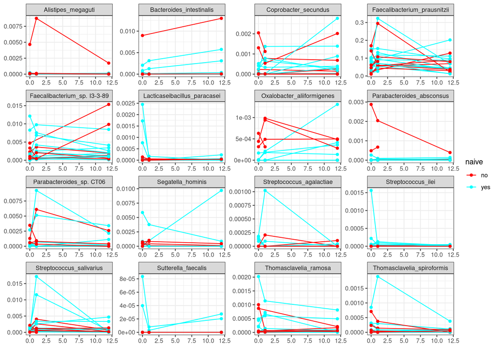

### Feature: age_at_T0

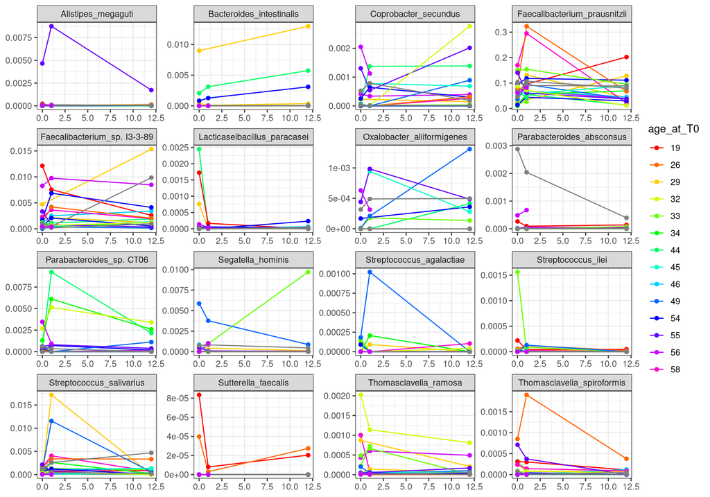

### Feature: therapy

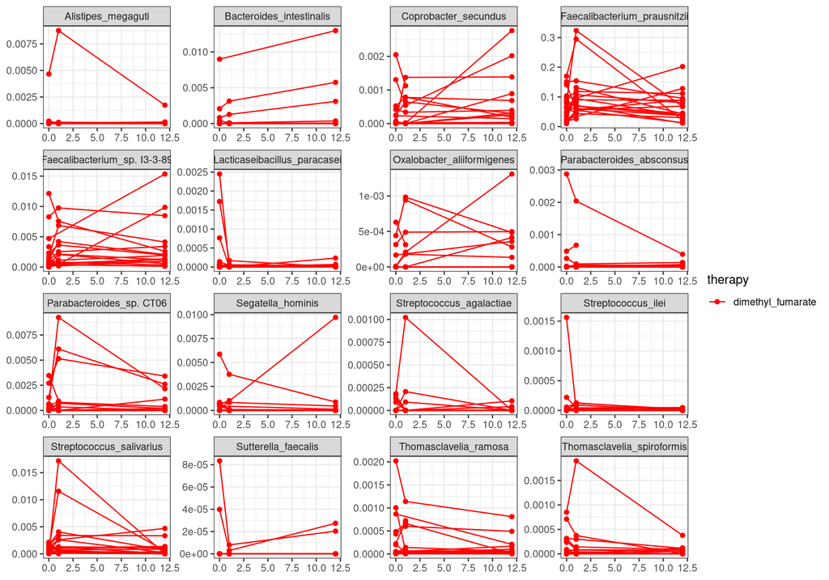

### Feature: bmi

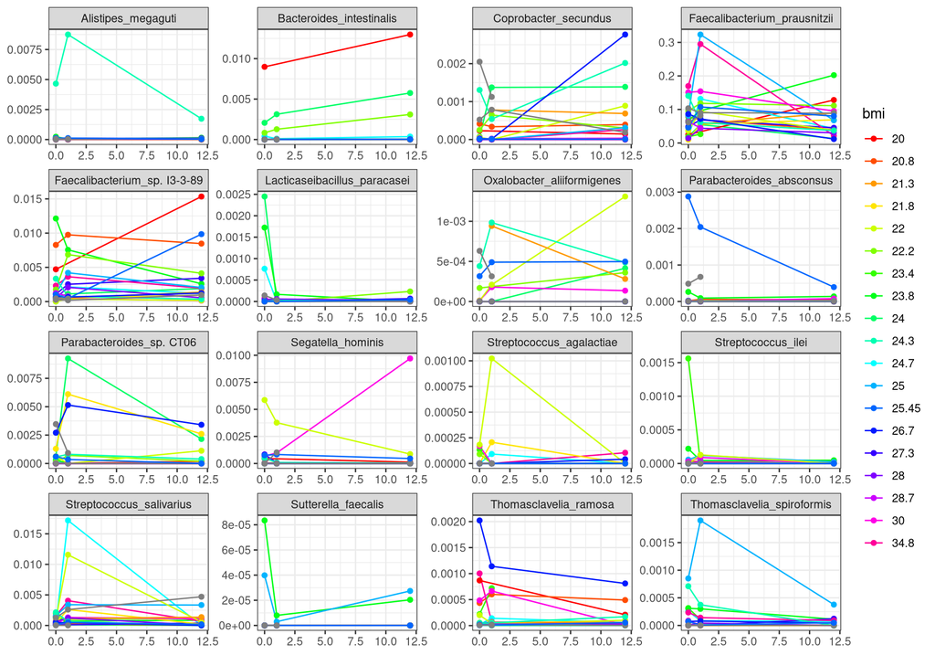

## Time Grid Visualization

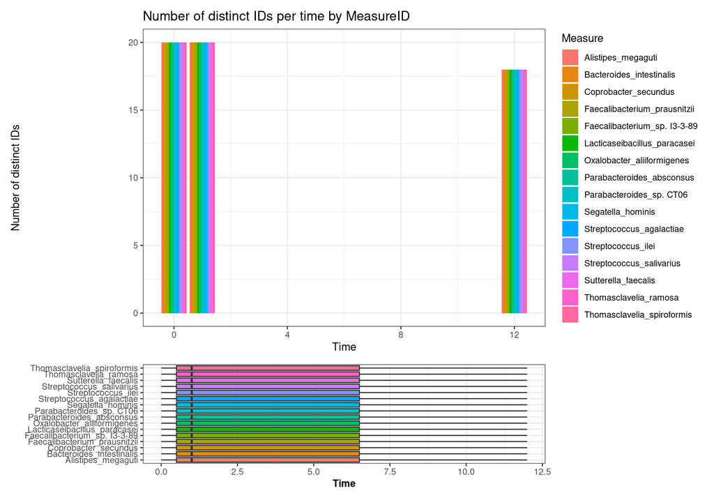

## Dimension Analysis

### Measure: Alistipes_megaguti

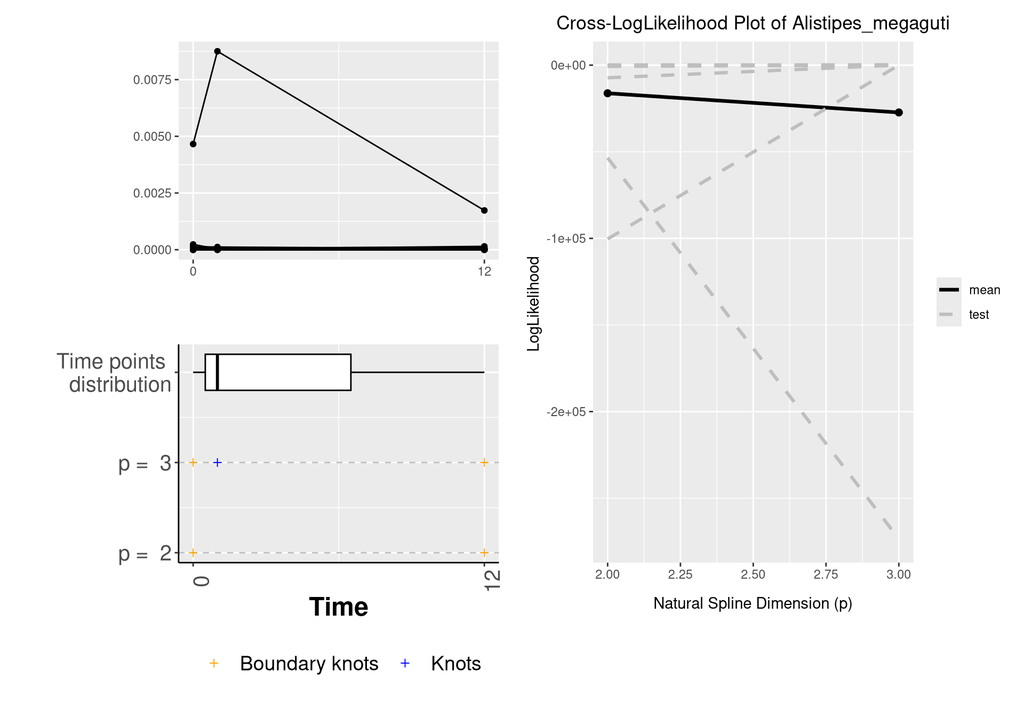

### Measure: Bacteroides_intestinalis

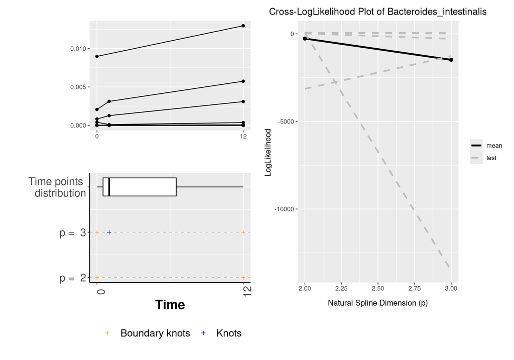

### Measure: Coprobacter_secundus

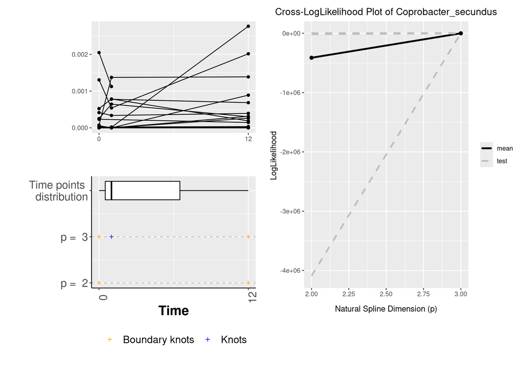

### Measure: Faecalibacterium_prausnitzii

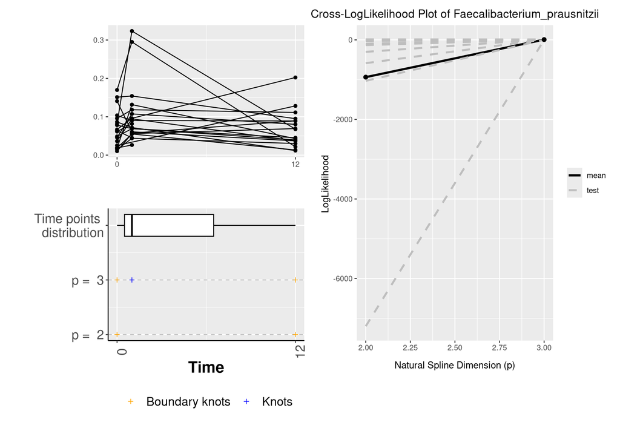

### Measure: Faecalibacterium_sp. I3-3-89

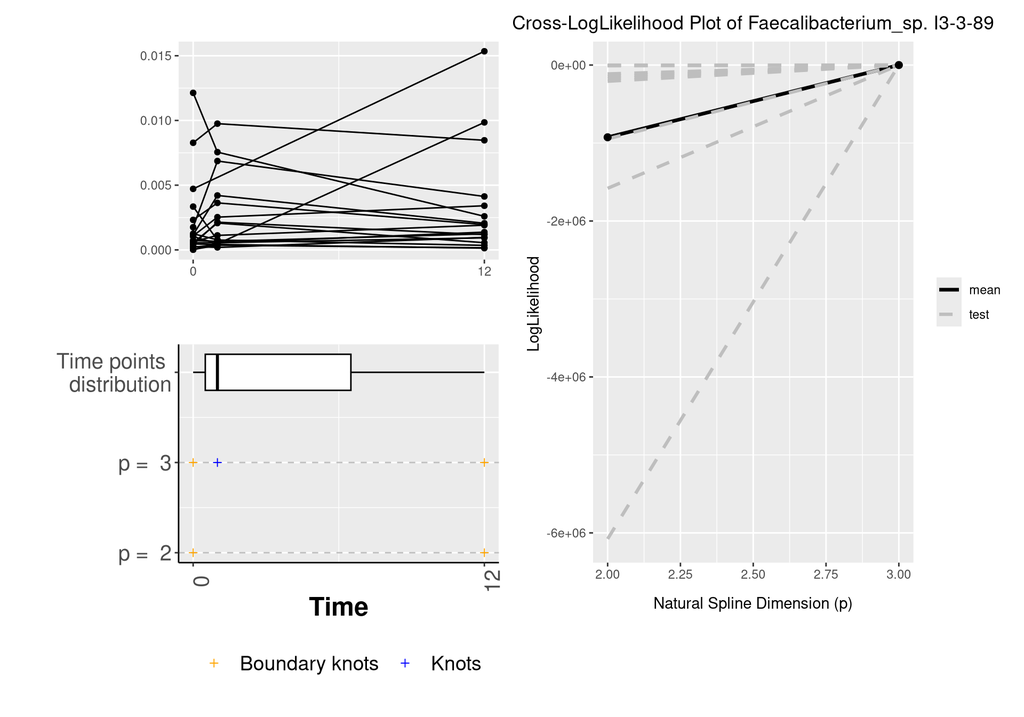

### Measure: Lacticaseibacillus_paracasei

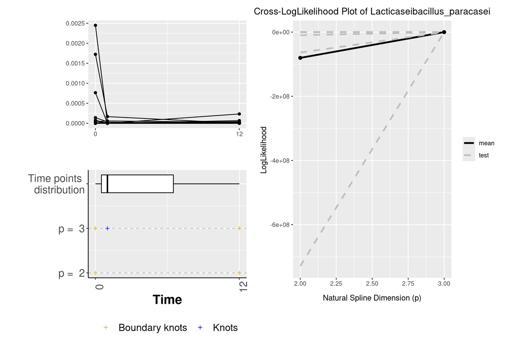

### Measure: Oxalobacter_aliiformigenes

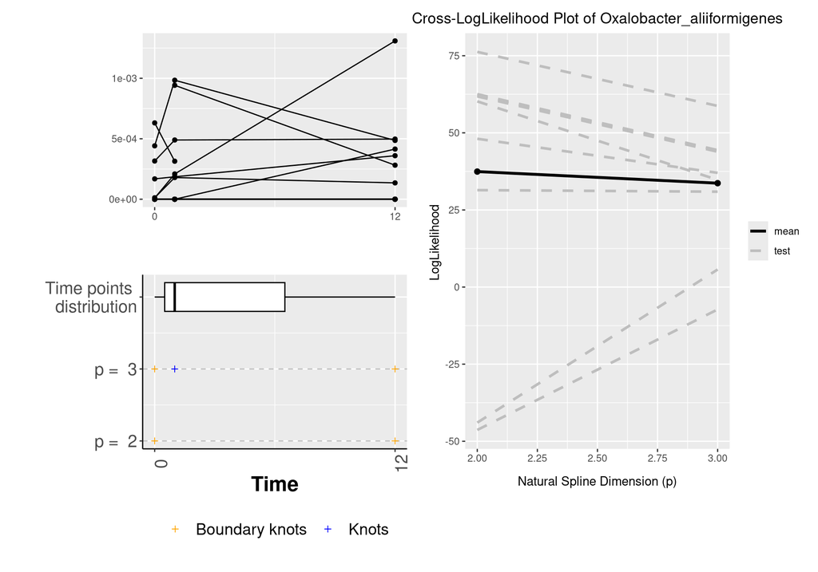

### Measure: Parabacteroides_absconsus

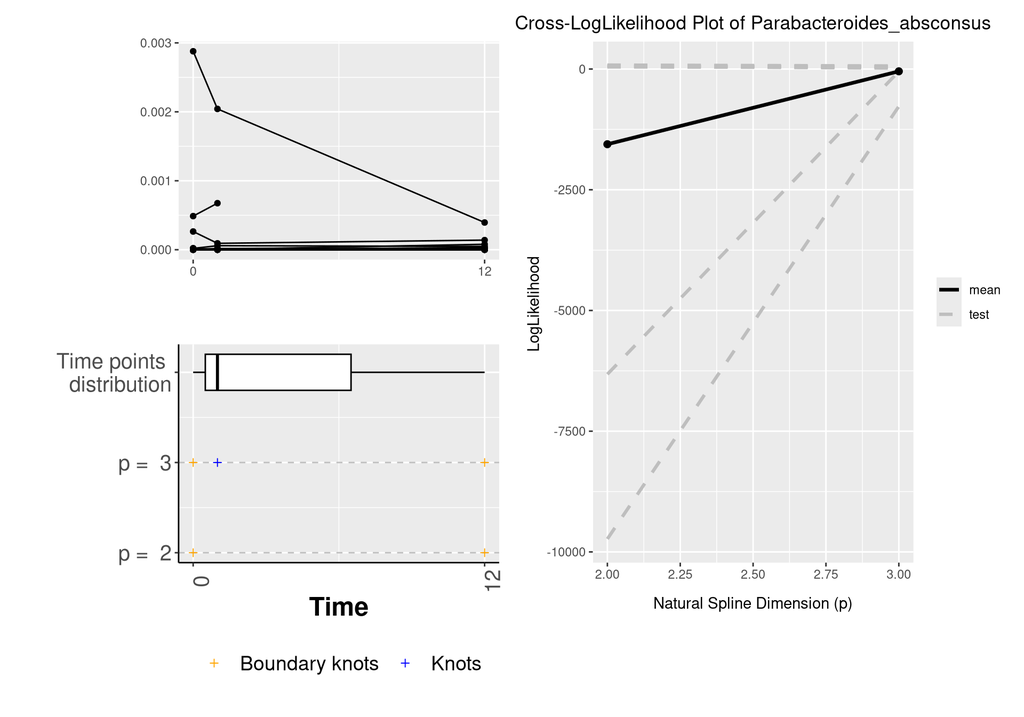

### Measure: Parabacteroides_sp. CT06

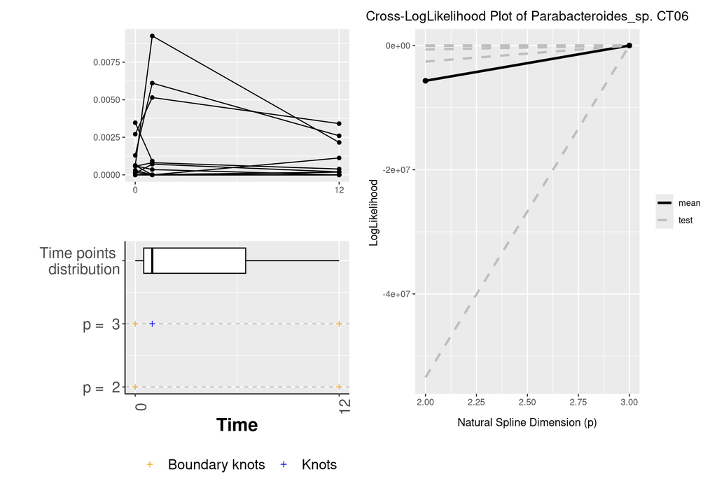

### Measure: Segatella_hominis

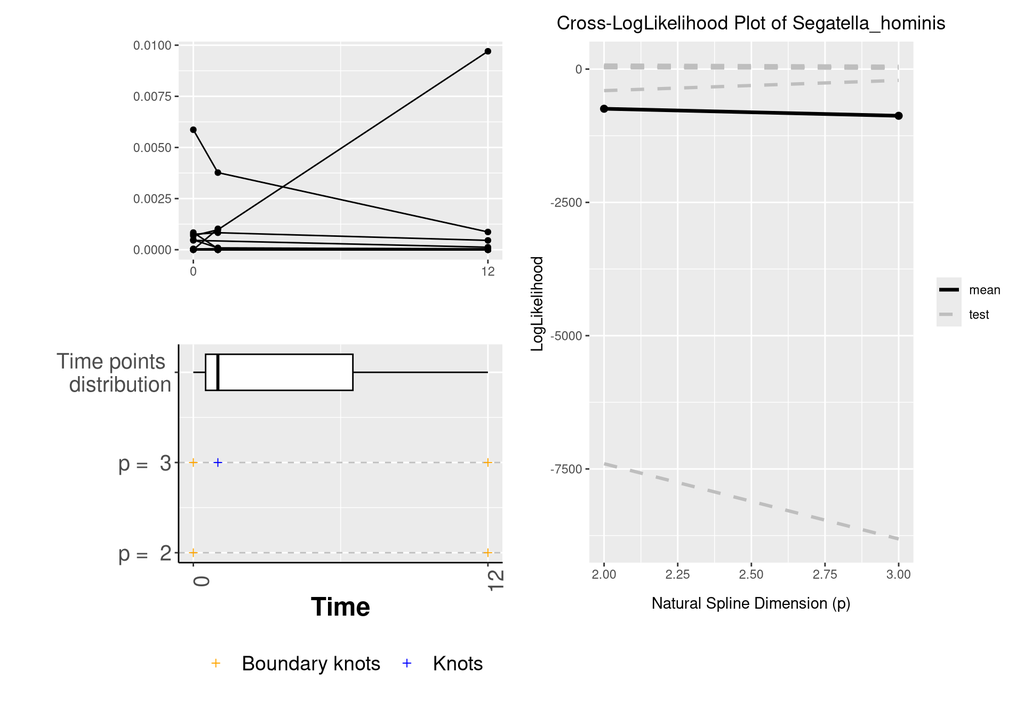

### Measure: Streptococcus_agalactiae

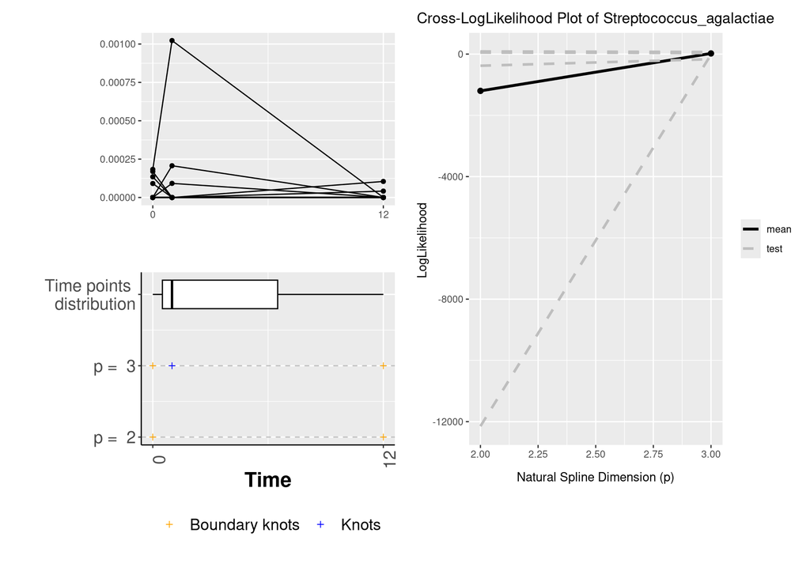

### Measure: Streptococcus_ilei

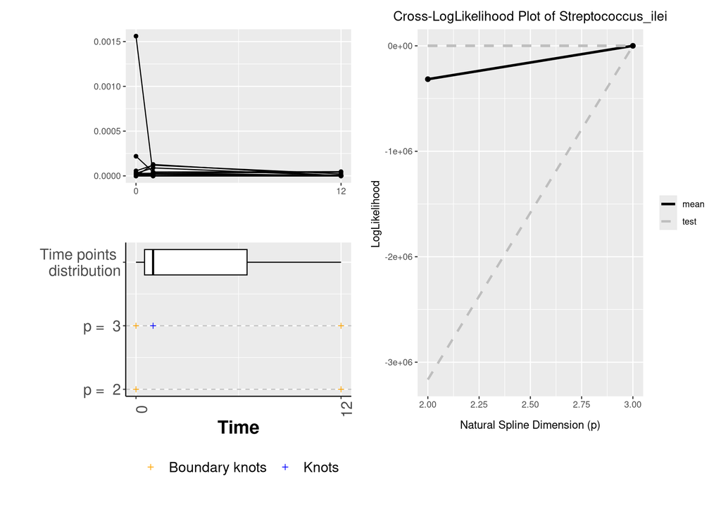

### Measure: Streptococcus_salivarius

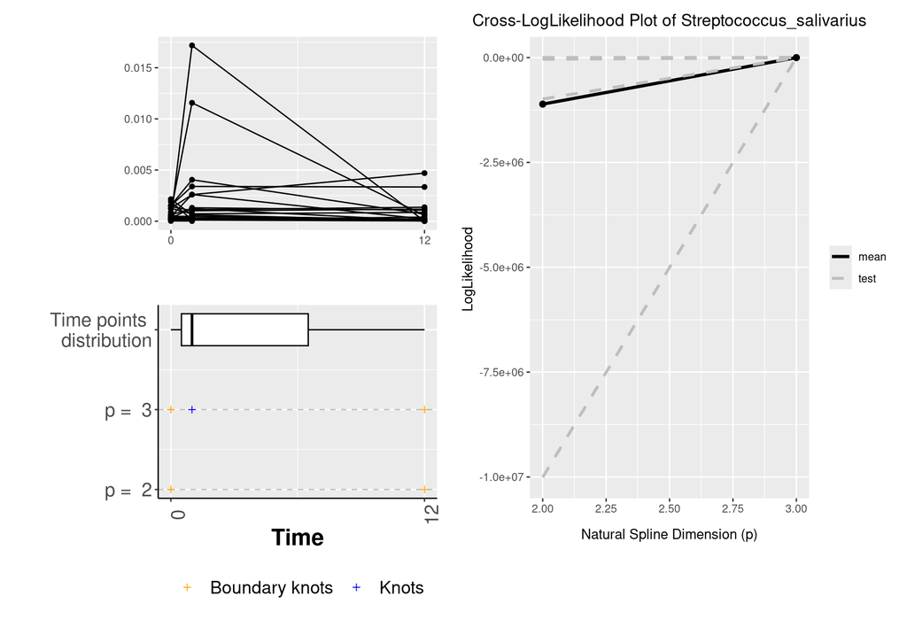

### Measure: Sutterella_faecalis

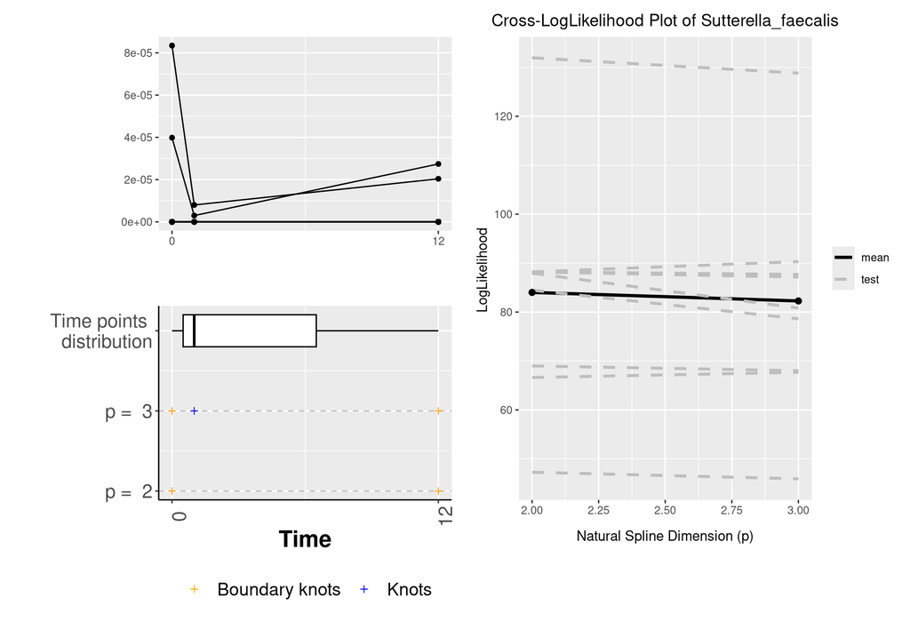

### Measure: Thomasclavelia_ramosa

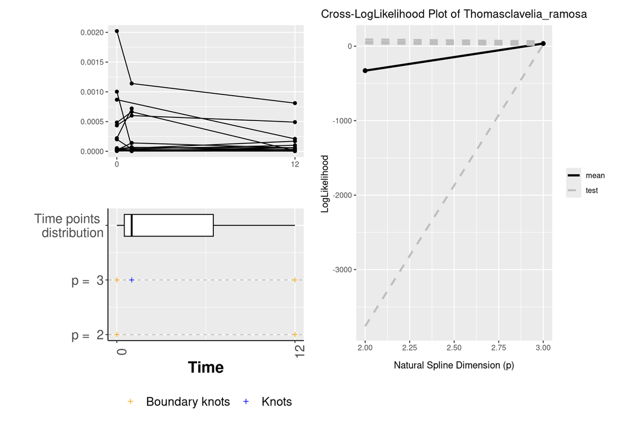

### Measure: Thomasclavelia_spiroformis

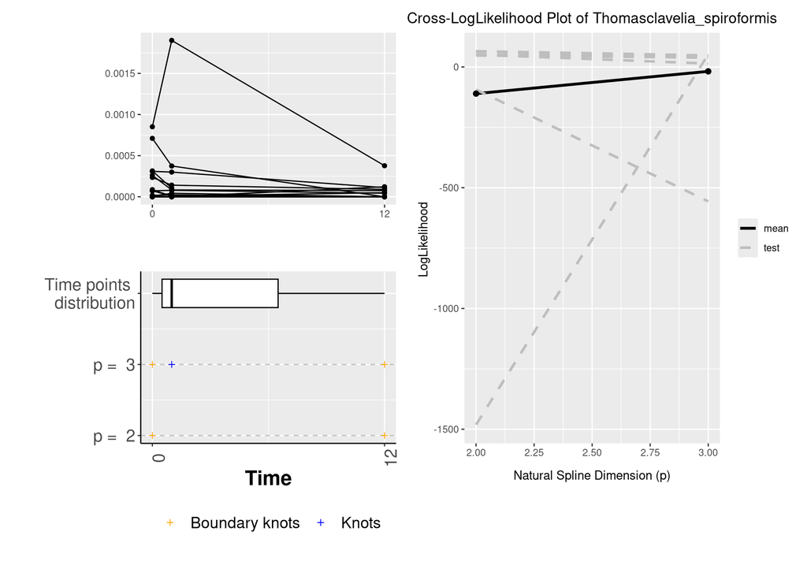

### Measure: summary

[output not shown]

### Measure: p_suggested

[output not shown]

## Cluster Selection Analysis

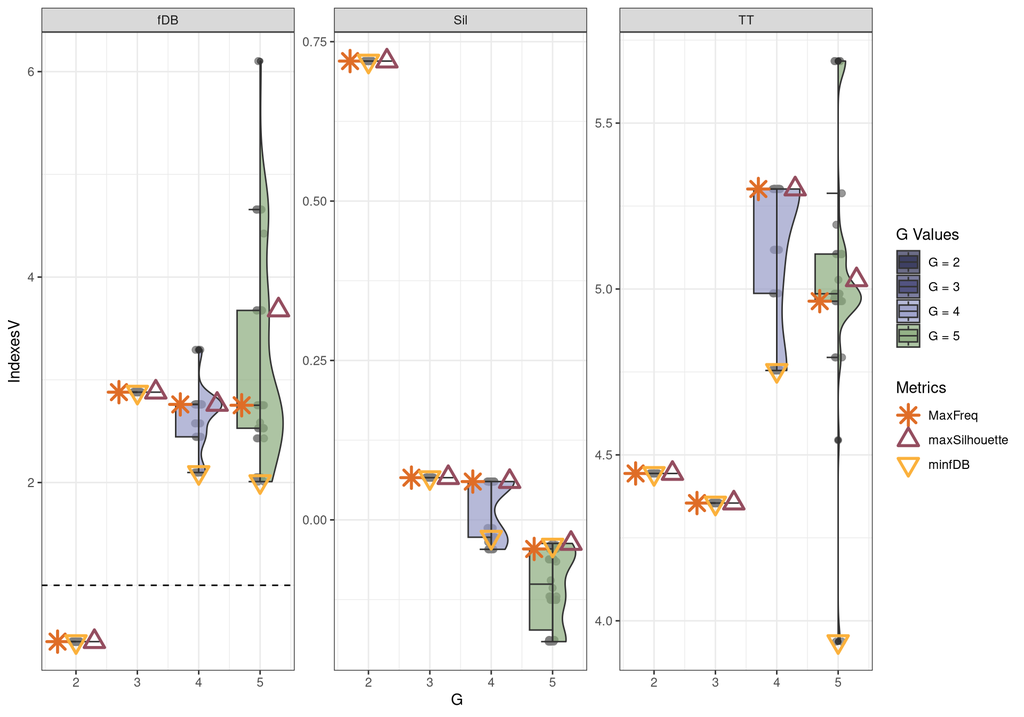

# Model Analysis: Model 1

## Model Summary

- **Number of clusters (G):** 2
- **H parameter:** 1
- **Spline dimensions (p):**
  - Alistipes_megaguti : 2
  - Bacteroides_intestinalis : 2
  - Coprobacter_secundus : 3
  - Faecalibacterium_prausnitzii : 3
  - Faecalibacterium_sp. I3-3-89 : 3
  - Lacticaseibacillus_paracasei : 3
  - Oxalobacter_aliiformigenes : 2
  - Parabacteroides_absconsus : 3
  - Parabacteroides_sp. CT06 : 3
  - Segatella_hominis : 2
  - Streptococcus_agalactiae : 3
  - Streptococcus_ilei : 3
  - Streptococcus_salivarius : 3
  - Sutterella_faecalis : 2
  - Thomasclavelia_ramosa : 3
  - Thomasclavelia_spiroformis : 3
- **Cluster names:** A, B

### Cluster Assignments

| Cluster | Size | Percentage |
| --- | --- | --- |
| A | 19 | 90.48 |
| B | 2 | 9.52 |

## Visualizations

### Base Classification

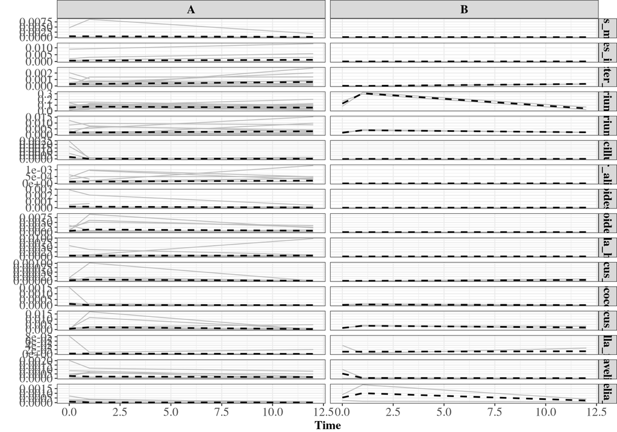

### Feature: EDSS_T0

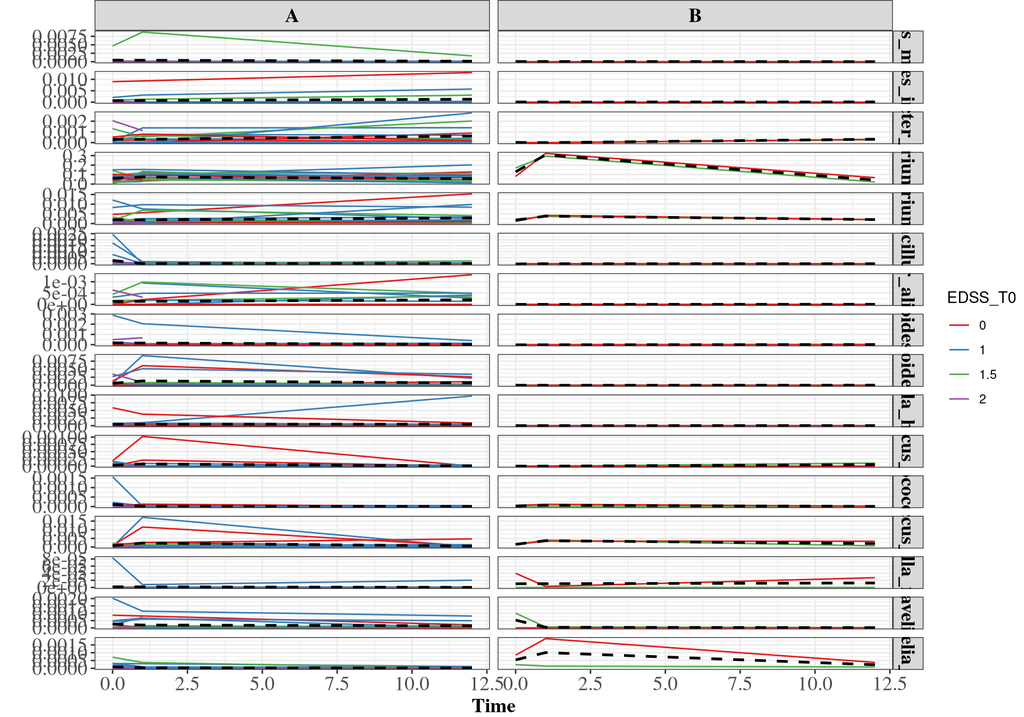

| EDSS_T0 | A | B | Total |
| --- | --- | --- | --- |
| 0 | 5 | 1 | 6 |
| 1 | 10 | 0 | 10 |
| 1.5 | 3 | 1 | 4 |
| 2 | 1 | 0 | 1 |
| TOTAL | 19 | 2 | 21 |
| TOTAL | 19 | 2 | 21 |

### Feature: EDSS_T12

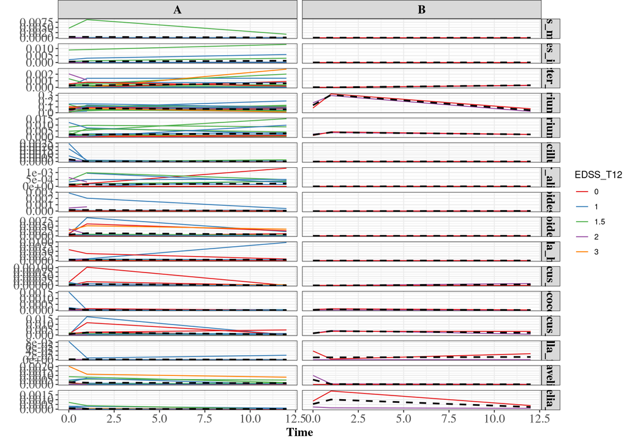

| EDSS_T12 | A | B | Total |
| --- | --- | --- | --- |
| 0 | 3 | 1 | 4 |
| 1 | 8 | 0 | 8 |
| 1.5 | 6 | 0 | 6 |
| 2 | 1 | 1 | 2 |
| 3 | 1 | 0 | 1 |
| TOTAL | 19 | 2 | 21 |
| TOTAL | 19 | 2 | 21 |

### Feature: sex

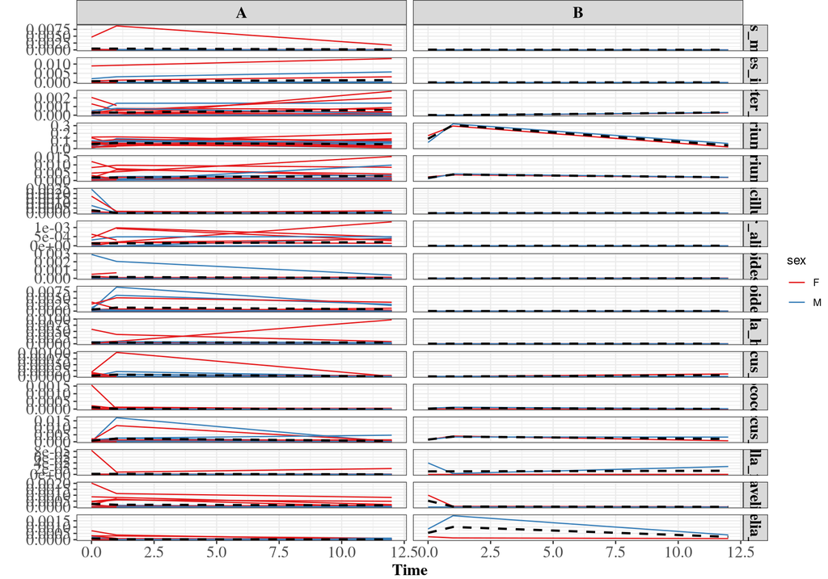

| sex | A | B | Total |
| --- | --- | --- | --- |
| F | 13 | 1 | 14 |
| M | 6 | 1 | 7 |
| TOTAL | 19 | 2 | 21 |
| TOTAL | 19 | 2 | 21 |

### Feature: naive

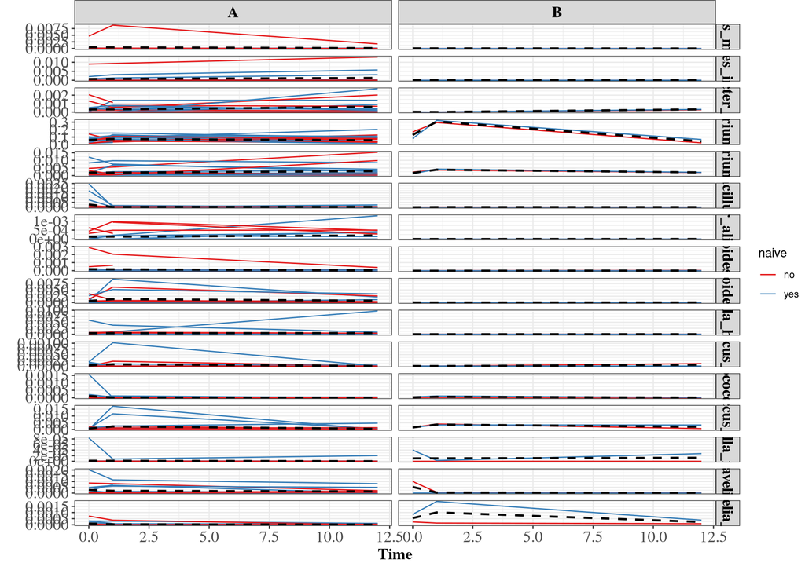

| naive | A | B | Total |
| --- | --- | --- | --- |
| no | 7 | 1 | 8 |
| yes | 12 | 1 | 13 |
| TOTAL | 19 | 2 | 21 |
| TOTAL | 19 | 2 | 21 |

### Feature: age_at_T0

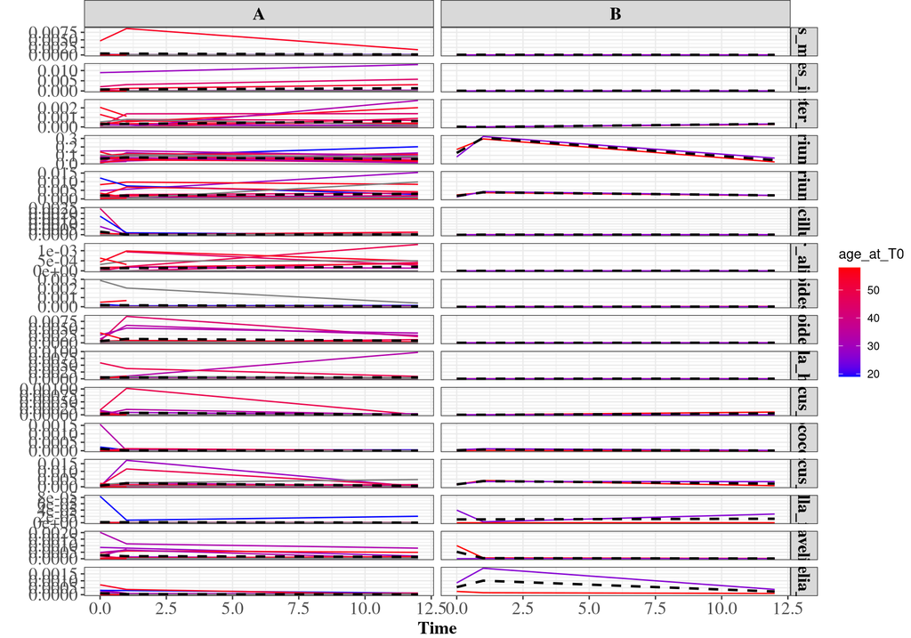

| age_at_T0 | A | B | Total |
| --- | --- | --- | --- |
| 19 | 1 | 0 | 1 |
| 29 | 2 | 0 | 2 |
| 32 | 1 | 0 | 1 |
| 33 | 2 | 0 | 2 |
| 34 | 1 | 0 | 1 |
| 44 | 2 | 0 | 2 |
| 45 | 1 | 0 | 1 |
| 46 | 1 | 0 | 1 |
| 49 | 1 | 0 | 1 |
| 54 | 2 | 0 | 2 |
| 55 | 1 | 0 | 1 |
| 56 | 2 | 0 | 2 |
| 26 | 0 | 1 | 1 |
| 58 | 0 | 1 | 1 |
| TOTAL | 17 | 2 | 19 |
| TOTAL | 17 | 2 | 19 |

### Feature: therapy

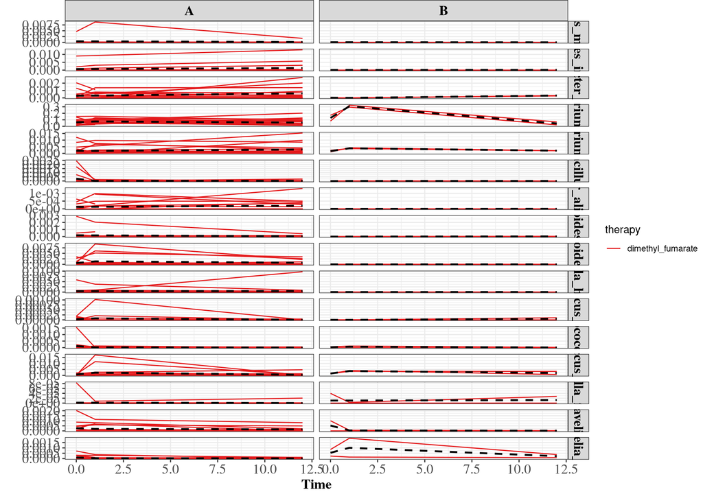

| therapy | A | B | Total |
| --- | --- | --- | --- |
| dimethyl_fumarate | 19 | 2 | 21 |
| TOTAL | 19 | 2 | 21 |
| TOTAL | 19 | 2 | 21 |

### Feature: bmi

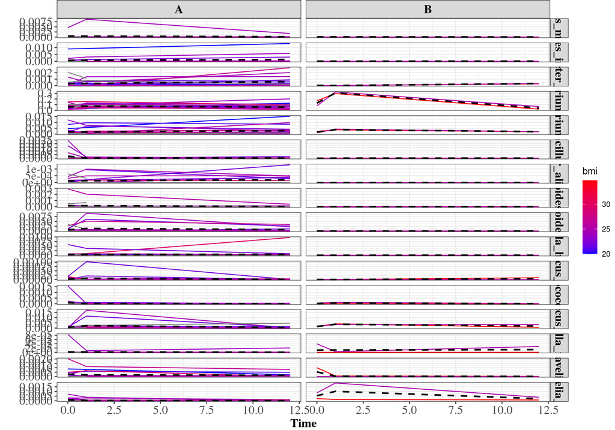

| bmi | A | B | Total |
| --- | --- | --- | --- |
| 20 | 1 | 0 | 1 |
| 20.8 | 1 | 0 | 1 |
| 21.3 | 1 | 0 | 1 |
| 21.8 | 1 | 0 | 1 |
| 22 | 1 | 0 | 1 |
| 22.2 | 1 | 0 | 1 |
| 23.4 | 1 | 0 | 1 |
| 23.8 | 1 | 0 | 1 |
| 24 | 1 | 0 | 1 |
| 24.3 | 1 | 0 | 1 |
| 24.7 | 1 | 0 | 1 |
| 25.45 | 1 | 0 | 1 |
| 26.7 | 1 | 0 | 1 |
| 27.3 | 1 | 0 | 1 |
| 28 | 1 | 0 | 1 |
| 28.7 | 1 | 0 | 1 |
| 30 | 1 | 0 | 1 |
| 25 | 0 | 1 | 1 |
| 34.8 | 0 | 1 | 1 |
| TOTAL | 17 | 2 | 19 |
| TOTAL | 17 | 2 | 19 |

## Validation

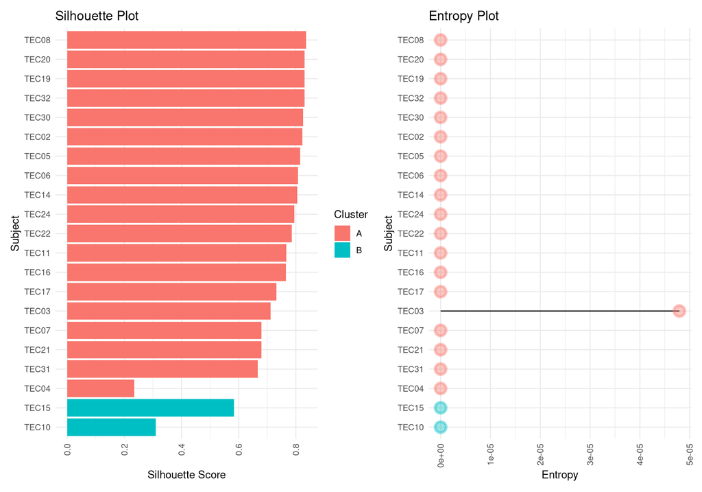

## Discriminant Analysis

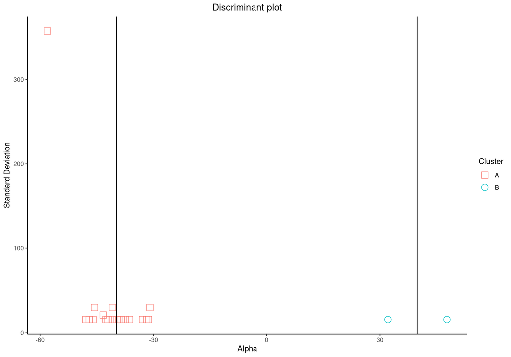

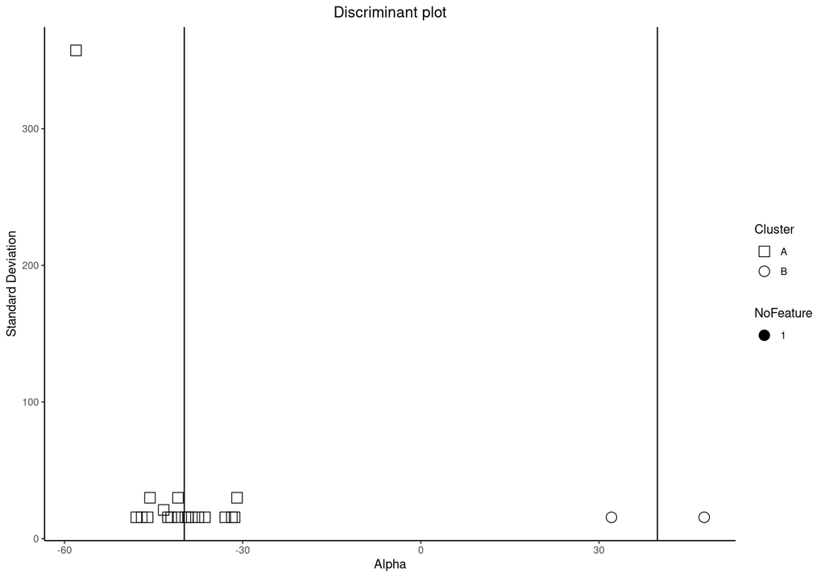

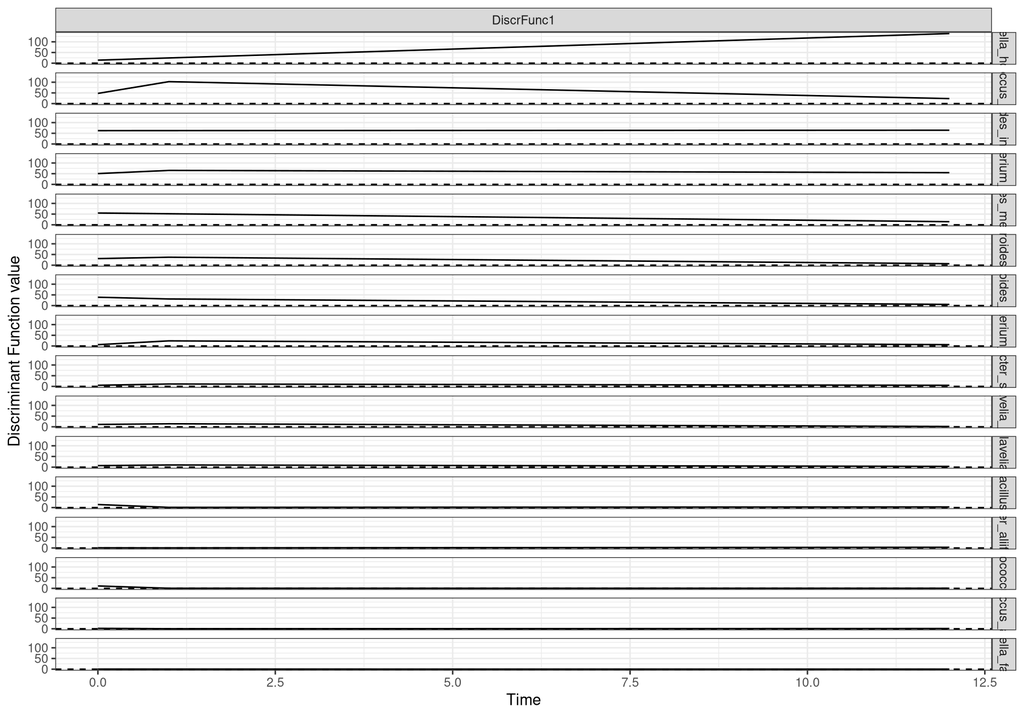

Relative importance of measures in clustering.

| measureID | TotalArea |
| --- | --- |
| Segatella_hominis | 916.902142 |
| Streptococcus_salivarius | 767.506926 |
| Bacteroides_intestinalis | 760.800700 |
| Faecalibacterium_sp. I3-3-89 | 718.819643 |
| Alistipes_megaguti | 416.738318 |
| Parabacteroides_sp. CT06 | 277.585113 |
| Parabacteroides_absconsus | 235.202101 |
| Faecalibacterium_prausnitzii | 181.069259 |
| Coprobacter_secundus | 97.503355 |
| Thomasclavelia_spiroformis | 97.287158 |
| Thomasclavelia_ramosa | 85.717890 |
| Lacticaseibacillus_paracasei | 29.001491 |
| Oxalobacter_aliiformigenes | 21.185366 |
| Streptococcus_ilei | 11.698319 |
| Streptococcus_agalactiae | 8.697329 |
| Sutterella_faecalis | 2.761690 |

*Report generated by MultiConnector R Package*